# Econometrics &amp; Panel Data

←Back to the bookChapter 99 · Econometrics & Panel Data

Chapter 99 · Econometrics & Panel Data

Econometrics & Panel Data

Watch omitted-variable bias inflate a pooled estimate, remove it with fixed effects, prove the fix against the hidden confounder, and recover a causal slope with two-stage least squares, library-first with statsmodels.

Statistics, Data Science and AI: A Visual Handbook · John Fisher · 2026

## Econometrics: pulling cause out of observational data

Library-first with `statsmodels`. We watch omitted-variable bias inflate a pooled estimate, remove it with fixed effects, prove the fix by revealing the hidden confounder, and run a two-stage least squares instrumental-variable demo.

```python
import numpy as np, pandas as pd, matplotlib.pyplot as plt
from scipy import stats
import seaborn as sns   # seaborn = high-level statistical plots (heatmaps, regplots, pairplots)
import statsmodels.api as sm
from statsmodels.formula.api import ols
from statsmodels.stats.outliers_influence import variance_inflation_factor
from statsmodels.nonparametric.smoothers_lowess import lowess
from sklearn.linear_model import LinearRegression, Ridge, Lasso, LogisticRegression
from sklearn.preprocessing import StandardScaler, PolynomialFeatures
from sklearn.pipeline import make_pipeline
from sklearn.model_selection import train_test_split, cross_val_score
from sklearn.metrics import r2_score, mean_squared_error
ORG="#ea580c"; DEEP="#c2410c"; LIGHT="#fdba74"; INK="#1a2138"; GRID="#e6e9f2"; GREEN="#059669"; RED="#ef4444"; AMBER="#d97706"; BLUE="#2563eb"; PUR="#9333ea"; GREY="#94a3b8"; SLATE="#475569"
plt.rcParams.update({"figure.facecolor":"white","axes.facecolor":"white","figure.dpi":110,"font.size":11,
   "axes.edgecolor":GRID,"axes.grid":True,"grid.color":GRID,"axes.axisbelow":True,"axes.spines.top":False,
   "axes.spines.right":False,"axes.titlesize":12,"axes.titleweight":"bold","legend.frameon":False})
sns.set_style("whitegrid")
BASE="https://raw.githubusercontent.com/johnfisher-ai/Statistics-Data-Science-AI-Visual-Book/main/data/"
```

DEMO 1 · THE BIASED ESTIMATE

Pooled OLS overstates the union premium

A plain regression ignores who unionizes, and unionizers differ in unmeasured ability.

```python
try:
    panel = pd.read_excel('../../data/econometrics-and-panel-data--panel.xlsx', sheet_name='Panel')
except FileNotFoundError:
    panel = pd.read_excel(BASE + 'econometrics-and-panel-data--panel.xlsx', sheet_name='Panel')
print(f'{panel.worker_id.nunique()} workers x {panel.year.nunique()} years = {len(panel)} rows')
print(f'corr(union, ability) = {panel[["union","ability_index"]].corr().iloc[0,1]:.2f}   (the endogeneity)')
panel.head(3)
```

```
160 workers x 4 years = 640 rows
corr(union, ability) = 0.37   (the endogeneity)
```

|  | worker_id | year | tenure | union | ability_index | log_wage | wage |
| --- | --- | --- | --- | --- | --- | --- | --- |
| 0 | W000 | 2021 | 8 | 1 | 0.082 | 3.210 | 24.78 |
| 1 | W000 | 2022 | 9 | 0 | 0.082 | 3.039 | 20.89 |
| 2 | W000 | 2023 | 10 | 0 | 0.082 | 3.263 | 26.12 |

```python
pooled = ols('log_wage ~ union + tenure', panel).fit()
b, (lo, hi) = pooled.params['union'], pooled.conf_int().loc['union']
print(f'Pooled OLS union coefficient = {b:.3f}  (95% CI {lo:.3f} to {hi:.3f})')
print('True premium built into the data = 0.15  ->  pooled OLS is biased UP.')
```

```
Pooled OLS union coefficient = 0.544  (95% CI 0.462 to 0.626)
True premium built into the data = 0.15  ->  pooled OLS is biased UP.
```

**Bias is not variance.** Notice the pooled estimate (about 0.54) comes with a *tight* confidence interval, it looks precise. But precise and correct are different things. The interval is narrow because we have plenty of data, yet it does not contain the true 0.15, because the error here is **bias** (a systematic tilt from the omitted ability), not sampling noise. More data would only shrink the interval further around the *wrong* number. Only a better design, not a bigger sample, can remove bias.

DEMO 2 · THE FIX

Fixed effects recover the truth

Add a per-worker intercept so only within-worker variation is used; time-invariant ability is differenced out.

```python
fe = ols('log_wage ~ union + tenure + C(worker_id)', panel).fit()
b, (lo, hi) = fe.params['union'], fe.conf_int().loc['union']
print(f'Fixed-effects union coefficient = {b:.3f}  (95% CI {lo:.3f} to {hi:.3f})')
print('Recovered the true ~0.15 premium, without ever measuring ability.')
```

```
Fixed-effects union coefficient = 0.152  (95% CI 0.123 to 0.181)
Recovered the true ~0.15 premium, without ever measuring ability.
```

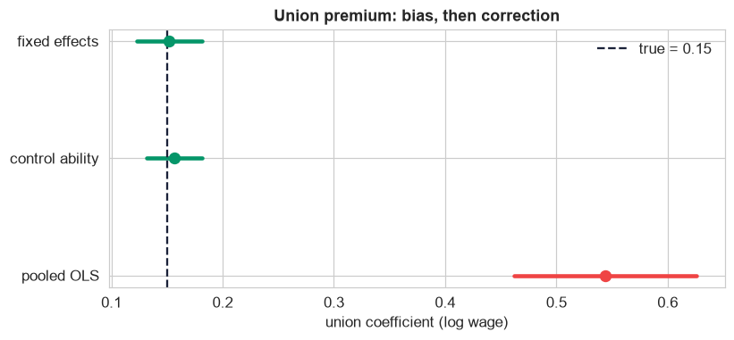

```python
# Show the correction visually: pooled vs FE vs truth
ctrl = ols('log_wage ~ union + tenure + ability_index', panel).fit()
ests = {'pooled OLS': pooled, 'control ability': ctrl, 'fixed effects': fe}
fig, ax = plt.subplots(figsize=(7.6,3.6))
for i,(name,m) in enumerate(ests.items()):
    lo,hi = m.conf_int().loc['union']; c = m.params['union']
    col = RED if name=='pooled OLS' else GREEN
    ax.plot([lo,hi],[i,i], color=col, lw=3); ax.scatter(c,i,color=col,s=60,zorder=3)
ax.axvline(0.15, color=INK, ls='--', label='true = 0.15')
ax.set_yticks(range(len(ests))); ax.set_yticklabels(list(ests.keys()))
ax.set(title='Union premium: bias, then correction', xlabel='union coefficient (log wage)'); ax.legend()
plt.tight_layout(); plt.show()
```

DEMO 3 · WHY IT WORKS

Fixed effects = controlling for the confounder you cannot see

Directly controlling for the hidden ability gives the same answer as fixed effects.

```python
print(f"control for ability : union = {ctrl.params['union']:.3f}")
print(f"fixed effects       : union = {fe.params['union']:.3f}")
print('Nearly identical: FE absorbs exactly the ability confounder, without needing to observe it.')
# Direction of omitted-variable bias = sign(corr(union,ability)) * sign(effect of ability)
print('\nOVB direction: union-ability corr > 0 and ability raises wage > 0  ->  upward bias, as seen.')
```

```
control for ability : union = 0.157
fixed effects       : union = 0.152
Nearly identical: FE absorbs exactly the ability confounder, without needing to observe it.

OVB direction: union-ability corr > 0 and ability raises wage > 0  ->  upward bias, as seen.
```

DEMO 4 · INSTRUMENTAL VARIABLES

Two-stage least squares on a simulated endogenous X

When a confounder is time-varying, fixed effects will not help. A valid instrument and 2SLS can.

```python
rng = np.random.default_rng(7); n = 2000
u = rng.normal(0, 1, n)                 # unobserved confounder
z = rng.normal(0, 1, n)                 # instrument (independent of u)
x = 0.8*z + 0.9*u + rng.normal(0,0.5,n) # endogenous: depends on z AND u
y = 2.0*x + 1.5*u + rng.normal(0,0.5,n) # true causal effect of x on y is 2.0
d = pd.DataFrame({'y':y,'x':x,'z':z})
ols_biased = ols('y ~ x', d).fit().params['x']
stage1 = ols('x ~ z', d).fit(); d['x_hat'] = stage1.fittedvalues
iv_2sls = ols('y ~ x_hat', d).fit().params['x_hat']
print(f'true causal effect       = 2.00')
print(f'naive OLS (biased by u)  = {ols_biased:.2f}')
print(f'2SLS with instrument z   = {iv_2sls:.2f}  (recovers the truth)')
```

```
true causal effect       = 2.00
naive OLS (biased by u)  = 2.77
2SLS with instrument z   = 2.00  (recovers the truth)
```

**How two-stage least squares works.** When the troublesome predictor X is correlated with the error (through a *time-varying* confounder that fixed effects cannot remove), we use an **instrument** Z, a variable that shifts X but affects Y only through X. Stage 1 regresses X on Z and keeps the fitted X-hat, the part of X explained by the instrument, scrubbed clean of the confounder. Stage 2 regresses Y on that X-hat. Here naive OLS was biased by the confounder u, but 2SLS with the valid instrument z recovered the true causal slope of 2.0. The catch in practice: a valid instrument must be *relevant* (it really moves X) and satisfy the *exclusion restriction* (it touches Y through no other path), which can be argued but never fully proven.

## Putting it all together: designing for cause

Econometrics asks a harder question than the earlier chapters: not 'does the model fit?' but 'does the design identify a *causal* effect?' Here is the full run.

**Step 1, check the threat.** We wanted the causal effect of union membership on wages. Union status was correlated with unobserved ability (r about 0.37), so the exogeneity condition failed, a plain regression would be biased.

**Steps 2-3, fit naively and diagnose.** Pooled OLS put the union premium at 0.54, more than triple the true 0.15, with a tight interval that did NOT contain the truth. That is bias, not variance: a confident wrong answer.

**Step 4, fix the design with fixed effects.** Because we had panel data (the same workers over time), fixed effects added a per-worker intercept and used only within-worker variation, differencing out time-invariant ability without ever measuring it. The estimate fell to 0.15, matching what we got by controlling for ability directly, proof the method works.

**When fixed effects are not enough: instrumental variables.** Fixed effects only remove *time-invariant* confounders. For a time-varying confounder, reverse causation, or measurement error, we used **two-stage least squares** with an instrument: naive OLS was biased, 2SLS recovered the true slope.

**Step 5, interpret.** A union coefficient of 0.15 on the log scale means wages are e^0.15 = 1.16 times higher, a 16% premium.

**Takeaway.** Clean residuals are necessary but not sufficient. The deepest question is whether the *design* identifies a causal effect, and fixed effects, instruments, and difference-in-differences are how econometrics answers it, closing the correlation-is-not-causation loop opened in Chapter 91.

Statistics, Data Science and AI: A Visual Handbook · © 2026 John Fisher

←Back to the bookChapter 99 · Econometrics & Panel Data